# Utiliser R Markdown pour créer des documents dynamiques

### Graphiques non générées par R

Dans la section traitant des images avec Pandoc Markdown nous avons vu comment insérer une image dans un document. Il est aussi possible de faire une telle inclusion grâce à la fonction `include_graphics()` de `knitr`. L’avantage de cette manière de procéder est qu’elle permet de traiter le fichier extérieur comme un graphique produit par R. Par exemple pour ajouter le logo de R utiliser plus haut (`./images/Rlogo.png`), il est possible d’utiliser:

````
``{r iclgraph, fig.align = 'center', out.width = "40%", echo = FALSE}
include_graphics("./images/Rlogo.png")
```
````

[figure not shown]

## Application, modèle linéaire dynamique

Supposons que je souhaite faire un modèle linéaire avec la variable explicative *var1* et la variable à expliquer *var2* de notre *tab1*. Pour ce faire je vais utiliser `lm()` et afficher les coefficients ainsi que les figures associés. J’utilise alors le bloc de code suivant :

````
``{r application, echo = FALSE, fig.cap = "Mon modèle linéaire", fig.width = 8,
    fig.height = 8, fig.align = 'center'}
mod1 <- lm(var2 ~ var1, data = tab1)
kable(summary(mod1)$coefficients)
par(bty = "l", mfrow = c(2, 2))
plot(mod1)
```
````

avec le commentaire suivant: "La pente de la regression est de `` `r format(summary(mod1)$coefficients[2, 1], digits = 3)` `` (et je mettrai le résultat en gras).

Le résultat est le suivant :

|  | Estimate | Std. Error | t value | Pr(>\|t\|) |
| --- | --- | --- | --- | --- |
| (Intercept) | 0.0334543 | 0.6478370 | 0.0516399 | 0.9598326 |
| var1 | 1.0264384 | 0.0593192 | 17.3036398 | 0.0000000 |

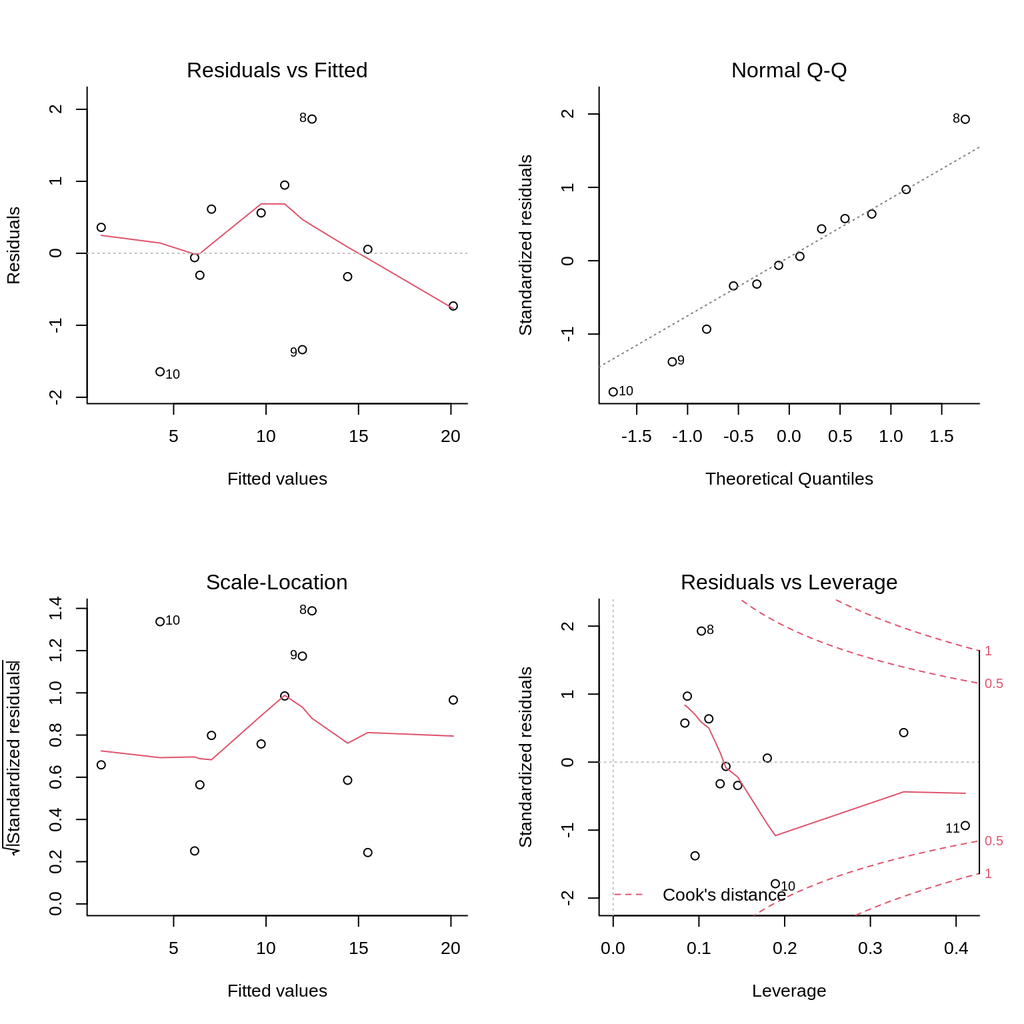

Mon modèle linéaire

La pente de la regression est de **1.03**.

Si je change les données de tab1, la table, les graphiques et mon commentaires seront changées de manière adéquates ce qui peut s’avérer très utile quand on a des rapports similaires à produire d’un mois à l’autre (ou d’une année sur l’autre).

# Références

Knauff, M., Nejasmic, J., 2014. An Efficiency Comparison of Document Preparation Systems Used in Academic Research and Development. PLoS One 9, e115069.

Lande, R., 1979. Quantitative Genetic Analysis of Multivariate Evolution , Applied to Brain : Body Size Allometry Russell Lande. Evolution (N. Y). 33, 402–416.

Oreskes, N., Shrader-Frechette, K., Belitz, K., 1994. Verification, validation, and confirmation of numerical models in the earth sciences. Science (80-. ). 263, 641–646.

Xie, Y., 2017. Dynamic documents with R and knitr. CRC Press, Boca Raton, Florida.

[^1]: https://en.wikipedia.org/wiki/John_Gruber, consulté le 1<sup>er</sup> juin 2020.
[^2]: https://fr.wikipedia.org/wiki/ReStructuredText, consulté le 1<sup>er</sup> juin 2020.
[^3]: https://blog.codinghorror.com/responsible-open-source-code-parenting/, consulté le 1<sup>er</sup> juin 2020.
[^4]: Par example Goldmark, https://github.com/yuin/goldmard, un parser Markdown écrit en Go et utilisé par Hugo (un générateur de site très populaire), est compatible avec Common Mark.
[^5]: La version 1 n’utilise pas Pandoc.
[^6]: Pandoc est d’ailleurs capable de gérer différentes variantes de Markdown.
[^7]: https://pandoc.org/MANUAL.html#pandocs-markdown, 1<sup>er</sup> juin 2020.
[^8]: voir https://pandoc.org/MANUAL.html#templates, consulté le 1<sup>er</sup> juin 2020.
[^9]: du contenu préliminaire.
[^10]: voir >https://fr.wikibooks.org/wiki/LaTeX/%C3%89crire_des_math%C3%A9matiques>, consulté le 2 juin 2020.
[^11]: Voir la section “Math” à l’URL suivant >https://pandoc.org/MANUAL.html#pandocs-markdown>, consulté le 2 juin 2020.
[^12]: https://cran.r-project.org/web/packages/yaml/index.html, consulté le 8 juin 2020.
[^13]: Le site de documentation est totalement écrit en Markdown et reprend ce que nous pouvons lire sur le [site de Pandoc](http://pandoc.org/demo/example9/pandocs-markdown.html) et que je reprend mais en français!
[^14]: Par exemple, avec HTML les deux paragraphes seront chacun des deux paragraphes seront des éléments paragraphes (balise `<p>`).
[^15]: Voir la section *Fenced code blocks* du manuel de référence https://pandoc.org/MANUAL.html.
[^16]: voir https://tex.stackexchange.com/questions/111868/pandoc-how-can-i-get-numbered-latex-equations-to-show-up-in-both-pdf-and-html-o)
[^17]: la première
[^18]: la seconde
[^19]: Les logiciels de gestion de bibliographie génèrent ces fichiers.

[figure not shown]